# EasyVisa_final

## EasyVisa Analysis

### Context

Business communities in the United States are facing high demand for human resources, but one of the constant challenges is identifying and attracting the right talent, which is perhaps the most important element in remaining competitive. Companies in the United States look for hard-working, talented, and qualified individuals both locally as well as abroad.

The Immigration and Nationality Act (INA) of the US permits foreign workers to come to the United States to work on either a temporary or permanent basis. The act also protects US workers against adverse impacts on their wages or working conditions by ensuring US employers' compliance with statutory requirements when they hire foreign workers to fill workforce shortages. The immigration programs are administered by the Office of Foreign Labor Certification (OFLC).

OFLC processes job certification applications for employers seeking to bring foreign workers into the United States and grants certifications in those cases where employers can demonstrate that there are not sufficient US workers available to perform the work at wages that meet or exceed the wage paid for the occupation in the area of intended employment.

### Objective

In FY 2016, the OFLC processed 775,979 employer applications for 1,699,957 positions for temporary and permanent labor certifications. This was a nine percent increase in the overall number of processed applications from the previous year. The process of reviewing every case is becoming a tedious task as the number of applicants is increasing every year.

The increasing number of applicants every year calls for a Machine Learning based solution that can help in shortlisting the candidates having higher chances of VISA approval. OFLC has hired the firm EasyVisa for data-driven solutions. You as a data scientist at EasyVisa have to analyze the data provided and, with the help of a classification model:

- 1. Facilitate the process of visa approvals.
- 2. Recommend a suitable profile for the applicants for whom the visa should be certified or denied based on the drivers that significantly influence the case status.

### Data Description

The data contains the different attributes of the employee and the employer. The detailed data dictionary is given below.

- case_id: ID of each visa application
- continent: Information of continent the employee
- education_of_employee: Information of education of the employee
- has_job_experience: Does the employee has any job experience? Y= Yes; N = No
- requires_job_training: Does the employee require any job training? Y = Yes; N = No
- no_of_employees: Number of employees in the employer's company
- yr_of_estab: Year in which the employer's company was established
- region_of_employment: Information of foreign worker's intended region of employment in the US.
- prevailing_wage: Average wage paid to similarly employed workers in a specific occupation in the area of intended employment. The purpose of the prevailing wage is to ensure that the foreign worker is not underpaid compared to other workers offering the same or similar service in the same area of employment.
- unit_of_wage: Unit of prevailing wage. Values include Hourly, Weekly, Monthly, and Yearly.
- full_time_position: Is the position of work full-time? Y = Full-Time Position; N = Part-Time Position
- case_status: Flag indicating if the Visa was certified or denied

### Import Libraries

```python
!pip install numpy==1.26.4 pandas==2.2.3 matplotlib==3.10.0 seaborn==0.13.2 scikit-learn==1.6.1 sklearn-pandas==2.2.0 xgboost==3.0.2 imbalanced-learn==0.13.0 -q
```

**Note:**

- After running the above cell, kindly restart the notebook kernel (for Jupyter Notebook) or runtime (for Google Colab) and run all cells sequentially from the next cell.

```python
# To help with reading and manipulating data
import pandas as pd
import numpy as np

# To help with data visualization
%matplotlib inline
import matplotlib.pyplot as plt
import seaborn as sns

# To be used for missing value imputation
from sklearn.impute import SimpleImputer


# To oversample and undersample data
from imblearn.over_sampling import SMOTE
from imblearn.under_sampling import RandomUnderSampler

# To help with model building
from sklearn.linear_model import LogisticRegression
from sklearn.tree import DecisionTreeClassifier
from sklearn.ensemble import (
    AdaBoostClassifier,
    GradientBoostingClassifier,
    RandomForestClassifier,
    BaggingClassifier,
)
from xgboost import XGBClassifier

# To get different metric scores, and split data
from sklearn import metrics
from sklearn.model_selection import train_test_split, StratifiedKFold, cross_val_score
from sklearn.metrics import (
    f1_score,
    accuracy_score,
    recall_score,
    precision_score,
    confusion_matrix,
    roc_auc_score,
    ConfusionMatrixDisplay,
)

# To be used for data scaling and one hot encoding
from sklearn.preprocessing import StandardScaler, MinMaxScaler, OneHotEncoder

# To be used for tuning the model
from sklearn.model_selection import GridSearchCV, RandomizedSearchCV

# To define maximum number of columns to be displayed in a dataframe
pd.set_option("display.max_columns", None)

# To supress scientific notations for a dataframe
pd.set_option("display.float_format", lambda x: "%.3f" % x)

# To supress warnings
import warnings
warnings.filterwarnings("ignore")
```

### Loading Data

```python
# Loading the dataset
data = pd.read_csv("EasyVisa.csv")
```

```python
# Checking the number of rows and columns in the data
data.shape
```

```
(25480, 12)
```

```python
# Create copy of data for protecting original data
data_copy = data.copy()
```

### Data Overview

#### View the first and last 5 rows of the dataset.

```python
# let's view the first 5 rows of the data
data.head()
```

|  | case_id | continent | education_of_employee | has_job_experience | requires_job_training | no_of_employees | yr_of_estab | region_of_employment | prevailing_wage | unit_of_wage | full_time_position | case_status |
| --- | --- | --- | --- | --- | --- | --- | --- | --- | --- | --- | --- | --- |
| 0 | EZYV01 | Asia | High School | N | N | 14513 | 2007 | West | 592.203 | Hour | Y | Denied |
| 1 | EZYV02 | Asia | Master's | Y | N | 2412 | 2002 | Northeast | 83425.650 | Year | Y | Certified |
| 2 | EZYV03 | Asia | Bachelor's | N | Y | 44444 | 2008 | West | 122996.860 | Year | Y | Denied |
| 3 | EZYV04 | Asia | Bachelor's | N | N | 98 | 1897 | West | 83434.030 | Year | Y | Denied |
| 4 | EZYV05 | Africa | Master's | Y | N | 1082 | 2005 | South | 149907.390 | Year | Y | Certified |

```python
# let's view the last 5 rows of the data
data.tail()
```

|  | case_id | continent | education_of_employee | has_job_experience | requires_job_training | no_of_employees | yr_of_estab | region_of_employment | prevailing_wage | unit_of_wage | full_time_position | case_status |
| --- | --- | --- | --- | --- | --- | --- | --- | --- | --- | --- | --- | --- |
| 25475 | EZYV25476 | Asia | Bachelor's | Y | Y | 2601 | 2008 | South | 77092.570 | Year | Y | Certified |
| 25476 | EZYV25477 | Asia | High School | Y | N | 3274 | 2006 | Northeast | 279174.790 | Year | Y | Certified |
| 25477 | EZYV25478 | Asia | Master's | Y | N | 1121 | 1910 | South | 146298.850 | Year | N | Certified |
| 25478 | EZYV25479 | Asia | Master's | Y | Y | 1918 | 1887 | West | 86154.770 | Year | Y | Certified |
| 25479 | EZYV25480 | Asia | Bachelor's | Y | N | 3195 | 1960 | Midwest | 70876.910 | Year | Y | Certified |

#### Understand the shape of the dataset.

```python
# Understanding shape of the data
data.shape
```

```
(25480, 12)
```

- The dataset has 25480 rows and 12 columns
- In essence, we have 25480 data points and 12 features for each data point.

#### Check the data types of the columns for the dataset.

```python
# let's check the data types of the columns in the dataset
data.info()
```

```
<class 'pandas.core.frame.DataFrame'>
RangeIndex: 25480 entries, 0 to 25479
Data columns (total 12 columns):
 #   Column                 Non-Null Count  Dtype
---  ------                 --------------  -----
 0   case_id                25480 non-null  object
 1   continent              25480 non-null  object
 2   education_of_employee  25480 non-null  object
 3   has_job_experience     25480 non-null  object
 4   requires_job_training  25480 non-null  object
 5   no_of_employees        25480 non-null  int64
 6   yr_of_estab            25480 non-null  int64
 7   region_of_employment   25480 non-null  object
 8   prevailing_wage        25480 non-null  float64
 9   unit_of_wage           25480 non-null  object
 10  full_time_position     25480 non-null  object
 11  case_status            25480 non-null  object
dtypes: float64(1), int64(2), object(9)
memory usage: 2.3+ MB
```

**Observations -**

- case_status is the dependent variable and it is object type.
- Number of employees, Establishment year and prevailing wage are numeric type.
- No NULL values for any of the feature across all data points.

#### Checking for duplicated values

```python
# let's check for duplicate values in the data
data.duplicated().sum()
```

```
0
```

- There are no duplicated rows in the dataset.

#### Checking for missing values

```python
# let's check for missing values in the data
round(data.isnull().sum() / data.isnull().count() * 100, 2)
```

```
case_id                 0.000
continent               0.000
education_of_employee   0.000
has_job_experience      0.000
requires_job_training   0.000
no_of_employees         0.000
yr_of_estab             0.000
region_of_employment    0.000
prevailing_wage         0.000
unit_of_wage            0.000
full_time_position      0.000
case_status             0.000
dtype: float64
```

```python
# Checking for the null value in the dataset
data.isna().sum()
```

```
case_id                  0
continent                0
education_of_employee    0
has_job_experience       0
requires_job_training    0
no_of_employees          0
yr_of_estab              0
region_of_employment     0
prevailing_wage          0
unit_of_wage             0
full_time_position       0
case_status              0
dtype: int64
```

- There are no missing values on the dataset

#### Dropping columns with all unique values

```python
data.nunique()
```

```
case_id                  25480
continent                    6
education_of_employee        4
has_job_experience           2
requires_job_training        2
no_of_employees           7105
yr_of_estab                199
region_of_employment         5
prevailing_wage          25454
unit_of_wage                 4
full_time_position           2
case_status                  2
dtype: int64
```

```python
data.drop(["case_id"], axis=1, inplace=True)
```

- All values in case_id column are unique which is expected, we can drop the column as it adds no value
- IDs are generally autogenerated to uniquely identify a case and hence don't necessarily reflect any case specific trait.

#### Statistical summary of the dataset

```python
# let's view the statistical summary of the numerical columns in the data
data.describe().T
```

|  | count | mean | std | min | 25% | 50% | 75% | max |
| --- | --- | --- | --- | --- | --- | --- | --- | --- |
| no_of_employees | 25480.000 | 5667.043 | 22877.929 | -26.000 | 1022.000 | 2109.000 | 3504.000 | 602069.000 |
| yr_of_estab | 25480.000 | 1979.410 | 42.367 | 1800.000 | 1976.000 | 1997.000 | 2005.000 | 2016.000 |
| prevailing_wage | 25480.000 | 74455.815 | 52815.942 | 2.137 | 34015.480 | 70308.210 | 107735.513 | 319210.270 |

```python
# Inspect unique units
print(data['unit_of_wage'].unique())

# Define conversion factors
conversion_factors = {
    'Hour': 2080,
    'Week': 52,
    'Month': 12,
    'Year': 1
}

# Normalize prevailing_wage to yearly wages
data['normalized_wage'] = data['prevailing_wage'] * data['unit_of_wage'].map(conversion_factors)

# View the statistical summary of normalized wages
print(data['normalized_wage'].describe())
```

```
['Hour' 'Year' 'Week' 'Month']
count      25480.000
mean      197391.155
std       578591.666
min          100.000
25%        47107.965
50%        82839.460
75%       124825.035
max     14569149.400
Name: normalized_wage, dtype: float64
```

**Observations**

- Average number of employees are 5667 but standard deviation of 22877 is very high indicating significant variability in companies.
- Minimum value for employees is negative indicating incorrect data entry and needs to be rectified.
- Maximum value of Employees is 602069 which is very high considering the 75th percentile which is 3504 indicating presence of outliers.
- Minimum value for year of establishment is 1800 which seems unrealistic for modern companies. It could be an outlier.
- The 25th percentile is 1976 and 75th percentile is 2005 for year of establishment which indicates that most companies were established in these years.
- Most recent year of establishment is 2016 which seems reasonable.
- Prevailing Wage has to be calculated after normalizing the data for varying units.
- Average prevailing wage is 197391.16 which a standard deviation of 578591.67 which is very high. This could be an indication of outliers in the data.
- Minimum wage is 100 which is unrealistic for yearly wage. This could be a data entry error or outlier.
- Maximum wage is 14569149.4 which is extremely high and is likely an outlier.
- Wage in 25th, 50th and 75th percentile are in reasonable range.

#### Analyzing Value counts for Categorical columns

```python
# Making a list of all catrgorical variables
categorical_columns = data.select_dtypes("object").columns.tolist()
print(categorical_columns)
```

```
['continent', 'education_of_employee', 'has_job_experience', 'requires_job_training', 'region_of_employment', 'unit_of_wage', 'full_time_position', 'case_status']
```

```python
from IPython.display import display, HTML

# Printing number of count of each unique value in each column
for column in categorical_columns:
    display(HTML(f"<pre>{data[column].value_counts()}</pre>"))
    print("-" * 40)
```

```
continent
Asia             16861
Europe            3732
North America     3292
South America      852
Africa             551
Oceania            192
Name: count, dtype: int64
```

```
education_of_employee
Bachelor's     10234
Master's        9634
High School     3420
Doctorate       2192
Name: count, dtype: int64
```

```
has_job_experience
Y    14802
N    10678
Name: count, dtype: int64
```

```
requires_job_training
N    22525
Y     2955
Name: count, dtype: int64
```

```
region_of_employment
Northeast    7195
South        7017
West         6586
Midwest      4307
Island        375
Name: count, dtype: int64
```

```
unit_of_wage
Year     22962
Hour      2157
Week       272
Month       89
Name: count, dtype: int64
```

```
full_time_position
Y    22773
N     2707
Name: count, dtype: int64
```

```
case_status
Certified    17018
Denied        8462
Name: count, dtype: int64
```

### EDA

#### Helper Functions

**The below functions need to be defined to carry out the EDA.**

```python
# function to plot a boxplot and a histogram along the same scale.


def histogram_boxplot(data, feature, figsize=(12, 7), kde=False, bins=None):
    """
    Boxplot and histogram combined

    data: dataframe
    feature: dataframe column
    figsize: size of figure (default (12,7))
    kde: whether to the show density curve (default False)
    bins: number of bins for histogram (default None)
    """
    f2, (ax_box2, ax_hist2) = plt.subplots(
        nrows=2,  # Number of rows of the subplot grid= 2
        sharex=True,  # x-axis will be shared among all subplots
        gridspec_kw={"height_ratios": (0.25, 0.75)},
        figsize=figsize,
    )  # creating the 2 subplots
    sns.boxplot(
        data=data, x=feature, ax=ax_box2, showmeans=True, color="violet"
    )  # boxplot will be created and a star will indicate the mean value of the column
    sns.histplot(
        data=data, x=feature, kde=kde, ax=ax_hist2, bins=bins, palette="winter"
    ) if bins else sns.histplot(
        data=data, x=feature, kde=kde, ax=ax_hist2
    )  # For histogram
    ax_hist2.axvline(
        data[feature].mean(), color="green", linestyle="--"
    )  # Add mean to the histogram
    ax_hist2.axvline(
        data[feature].median(), color="black", linestyle="-"
    )  # Add median to the histogram


# function to create labeled barplots


def labeled_barplot(data, feature, perc=False, n=None):
    """
    Barplot with percentage at the top

    data: dataframe
    feature: dataframe column
    perc: whether to display percentages instead of count (default is False)
    n: displays the top n category levels (default is None, i.e., display all levels)
    """

    total = len(data[feature])  # length of the column
    count = data[feature].nunique()
    if n is None:
        plt.figure(figsize=(count + 1, 5))
    else:
        plt.figure(figsize=(n + 1, 5))

    plt.xticks(rotation=90, fontsize=15)
    ax = sns.countplot(
        data=data,
        x=feature,
        palette="Paired",
        order=data[feature].value_counts().index[:n].sort_values(),
    )

    for p in ax.patches:
        if perc == True:
            label = "{:.1f}%".format(
                100 * p.get_height() / total
            )  # percentage of each class of the category
        else:
            label = p.get_height()  # count of each level of the category

        x = p.get_x() + p.get_width() / 2  # width of the plot
        y = p.get_height()  # height of the plot

        ax.annotate(
            label,
            (x, y),
            ha="center",
            va="center",
            size=12,
            xytext=(0, 5),
            textcoords="offset points",
        )  # annotate the percentage

    plt.show()  # show the plot
```

#### Univariate Analysis

```python
print("Categorical columns : \n", "\n".join(data_copy.select_dtypes("object").columns.tolist()))
print("Numerical columns : \n", "\n".join(data_copy.select_dtypes("number").columns.tolist()))
```

```
Categorical columns :
 case_id
continent
education_of_employee
has_job_experience
requires_job_training
region_of_employment
unit_of_wage
full_time_position
case_status
Numerical columns :
 no_of_employees
yr_of_estab
prevailing_wage
```

##### Observations on Continent

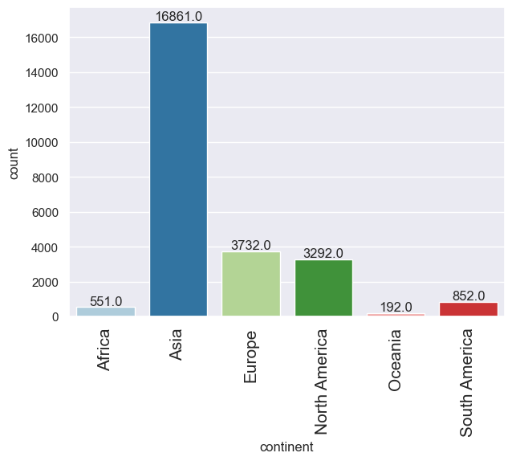

```python
# Observations on continent
labeled_barplot(data_copy, "continent")
```

- There are 6 different continents present in the data.
- Asia is the most prominetly occuring continent with almost 66% employees.
- Europe and North America have moderate representation.
- Oceania continent has the minimum employee count.
- There is a clear imbalance in employee distribution across continents.

##### Observations on Education of Employees

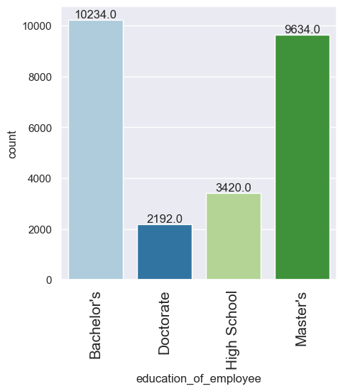

```python
# Observations on education_of_employee
labeled_barplot(data_copy, "education_of_employee")
```

- Majority of employees (~78%) hold either Bachelor's degree or Master's degree indicating highly educated workforce.
- Small group of employees (~13%) have only high school education.
- Smallest group are employees(~9%) with Doctorate, indicating limited number of highly specialized professionals.

##### Observations on Job Experience

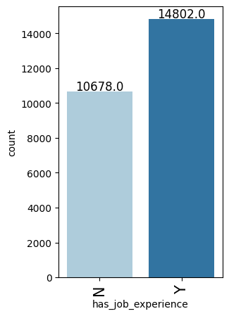

```python
# Observations on has_job_experience
labeled_barplot(data, "has_job_experience")
```

- Larger proportion of employees have prior job experience indicating a preference for hiring experienced professionals.
- Significant portion of employees have no prior experience indicating ample opportunities for entry level candidates.

##### Observations on Need for Job Training

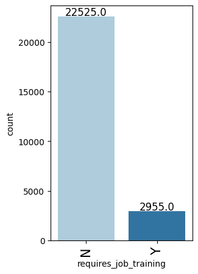

```python
# Observations on requires_job_training
labeled_barplot(data, "requires_job_training")
```

- Majority of employees (~88%) do not require job training indicating that most hires are already skilled.
- A smaller group of employees require job training indicating that some roles/employees may need additional preparation to meet job requirements.
- Data reflects a focus on hiring qualified candidates that are ready to perform in their roles without training.

##### Observations on Employment Region

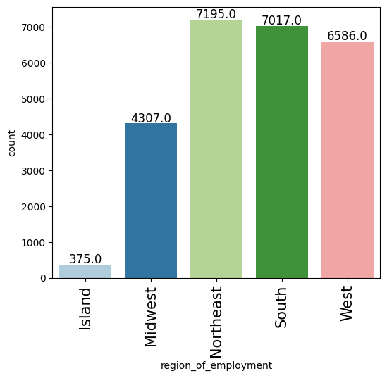

```python
# Observations on region_of_employment
labeled_barplot(data, "region_of_employment")
```

- Northeast (7,195), South (7,017), and West (6,586) regions have the highest employment counts, indicating a concentration of jobs in these areas.
- Midwest region (4,307) has moderate representation compared to the dominant regions.
- Island region (375) has the lowest employment count, suggesting limited job opportunities or smaller workforce requirements in this area.
- Employment is heavily skewed toward the Northeast, South, and West, reflecting regional economic activity and workforce demand.

##### Observations on Units of Wages

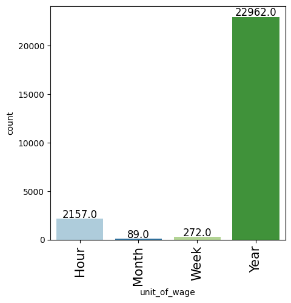

```python
# Observations on unit_of_wage
labeled_barplot(data, "unit_of_wage")
```

- Majority of employees(~90%) have their wages reported on yearly basis indicating a preference for annual salary structure.
- A smaller portion of employees(~8%) are paid hourly, likely representing roles with flexible or part time arrangements.
- Weekly and Monthly wage structures are very rare.
- Dominance of yearly wages simplifies comparisons and analysis, but the presence of other units highlights the need for normalization during data preprocessing.

##### Observations on Full time position

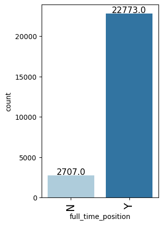

```python
# Observations on full_time_position
labeled_barplot(data, "full_time_position")
```

- Majority of employees (~89%) hold a full time position, indicating a preference for stable, long-term employment arrangements.
- A smaller portion of employees (~11%) are in part-time positions, suggesting limited opportunities for flexible or reduced-hour roles.
- Workforce is heavily skewed towards full time positions.

##### Observations on Case Status

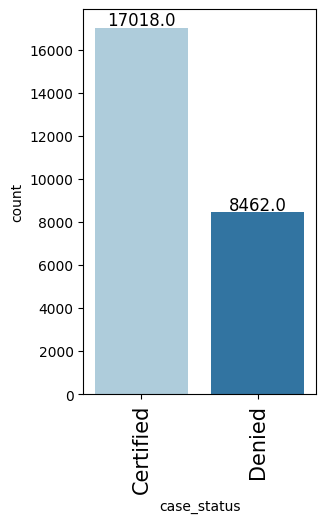

```python
# Observations on full_time_position
labeled_barplot(data, "case_status")
```

- Majority of cases (~67%) are certified, indicating a high success rate for applications.
- A significant number of cases (~33%~) are denied, suggesting room for improvement in meeting application requirements or eligibility criteria.
- Substantial denial count highlights potential challenges in the application process.

##### Observations on Number of Employees

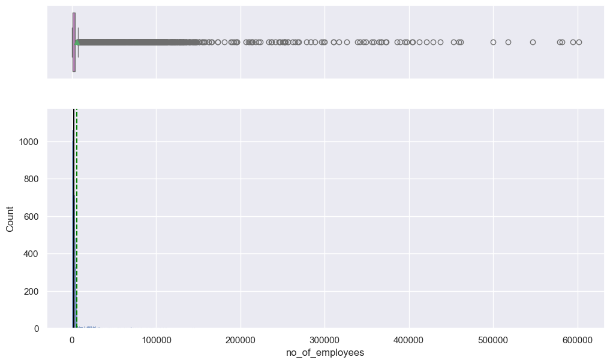

```python
# Observations on no_of_employees
histogram_boxplot(data_copy, "no_of_employees")
```

- The number of employees is heavily skewed, with most companies having a very small workforce.
- There are extreme outliers with employee counts reaching up to 600,000, which significantly distorts the distribution.
- The majority of companies have fewer than 5,000 employees, as indicated by the dense clustering near the lower end of the histogram.
- Negative values and extreme outliers should be investigated and handled appropriately

##### Observations on Year of Establishment

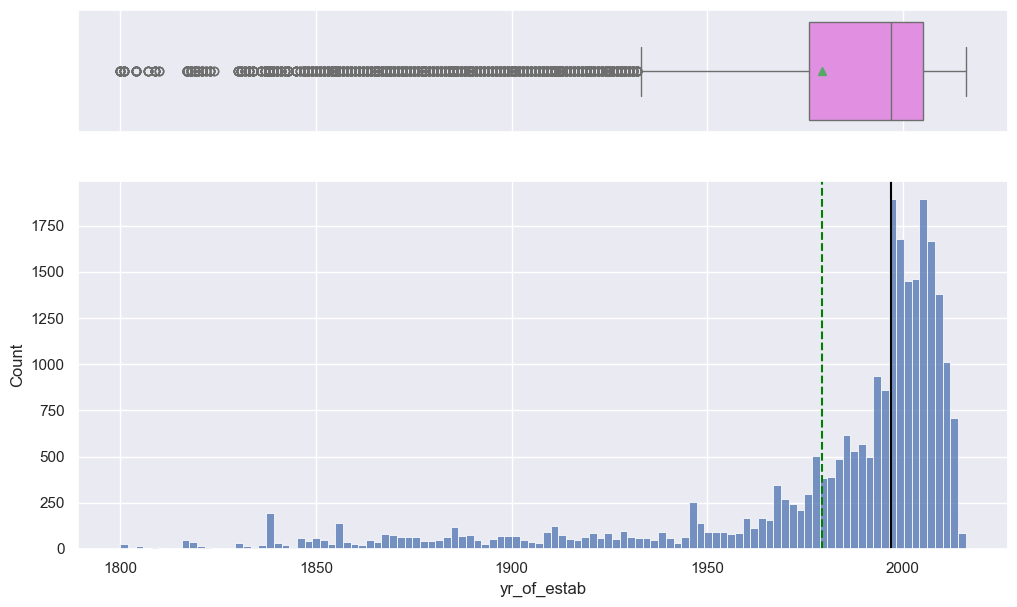

```python
# Observations on yr_of_estab
histogram_boxplot(data_copy, "yr_of_estab")
```

##### Observations on Prevailing Wage

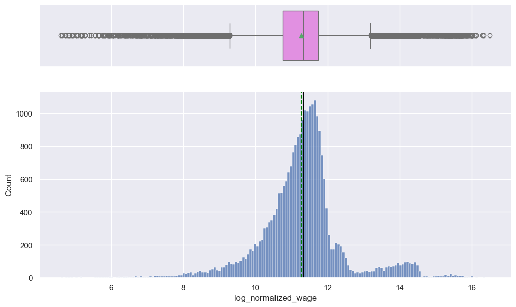

```python
# Observations on prevailing_wage
temp_copy = data.copy()
temp_copy['log_normalized_wage'] = np.log1p(temp_copy['normalized_wage'])
histogram_boxplot(temp_copy, "log_normalized_wage")
```

- The log transformation has significantly reduced the skewness, resulting in a more symmetric distribution of normalized wages.
- Most wages are concentrated between log values of approximately 10 and 12, corresponding to yearly wages between ~20,000 and ~160,000.
- While outliers are still present, they are less visually dominant after the transformation, making the distribution easier to interpret.
- The histogram now provides better granularity for the majority of wage values, allowing for more meaningful analysis.
- The interquartile range (IQR) is clearer, showing that most wages fall within a reasonable range, with fewer extreme values.

#### Bivariate Analysis

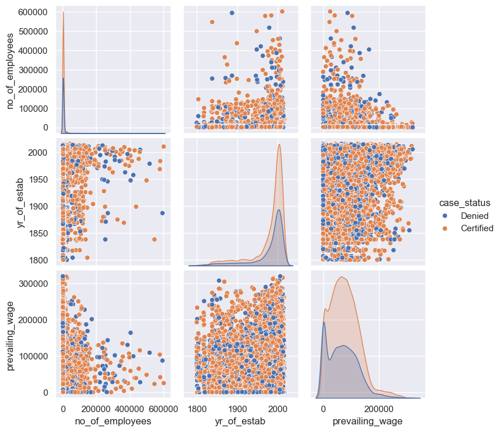

```python
_ = sns.pairplot(data_copy, hue="case_status")
plt.show()
```

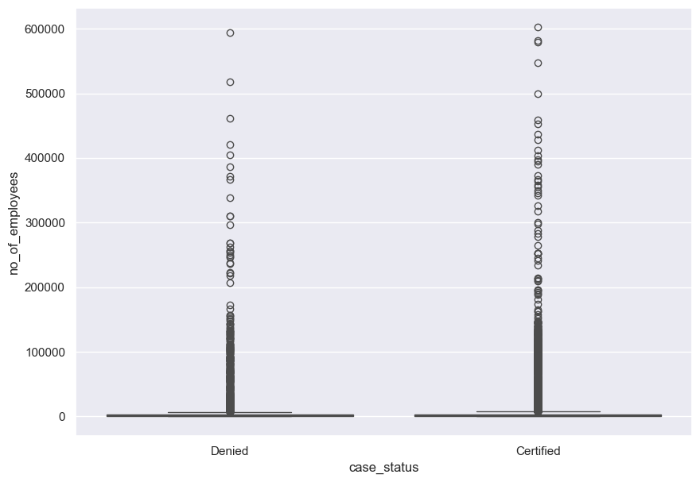

```python
sns.set(rc={"figure.figsize": (10, 7)})
_ = sns.boxplot(x="case_status", y="no_of_employees", data=data_copy, orient="vertical")
plt.show()
```

- Both Denied and Certified cases show a similar distribution of no_of_employees, with most values concentrated near the lower end. This suggests that employee count may not be a strong differentiator between case statuses.
- There are extreme outliers with employee counts exceeding 500,000 for both Denied and Certified cases. These outliers distort the visualization and may need to be capped.
- The majority of companies have fewer than 10,000 employees, as indicated by the dense clustering near the bottom of the boxplot.
- There is no clear trend or separation in no_of_employees between Denied and Certified cases, indicating that this feature alone may not strongly influence case outcomes.

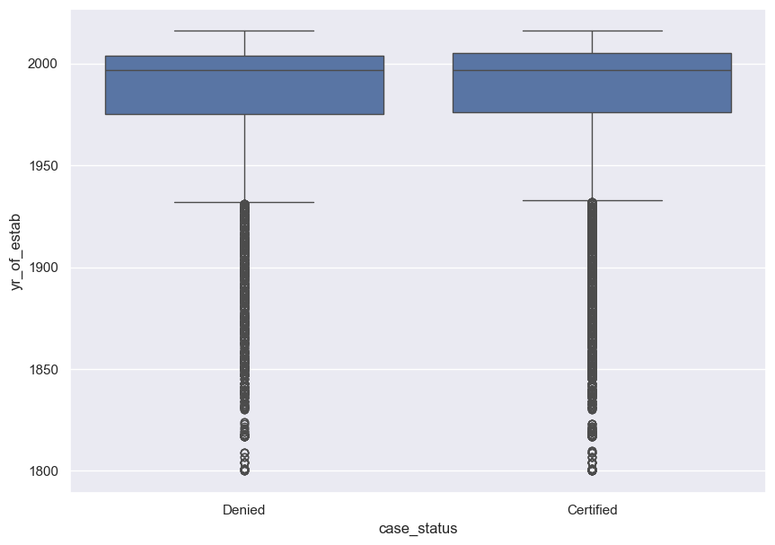

```python
sns.set(rc={"figure.figsize": (10, 7)})
_ = sns.boxplot(x="case_status", y="yr_of_estab", data=data_copy, orient="vertical")
plt.show()
```

- Both Denied and Certified cases have a similar distribution of yr_of_estab, with most companies established after 1950. This suggests that the year of establishment may not strongly differentiate case outcomes.
- There are outliers with establishment years before 1900 for both Denied and Certified cases. These values are likely erroneous and should be investigated or removed.
- The interquartile range (IQR) shows that most companies were established between 1975 and 2005, reflecting modern businesses.
- There is no significant separation in yr_of_estab between Denied and Certified cases, indicating that this feature alone may not be a strong predictor of case status.

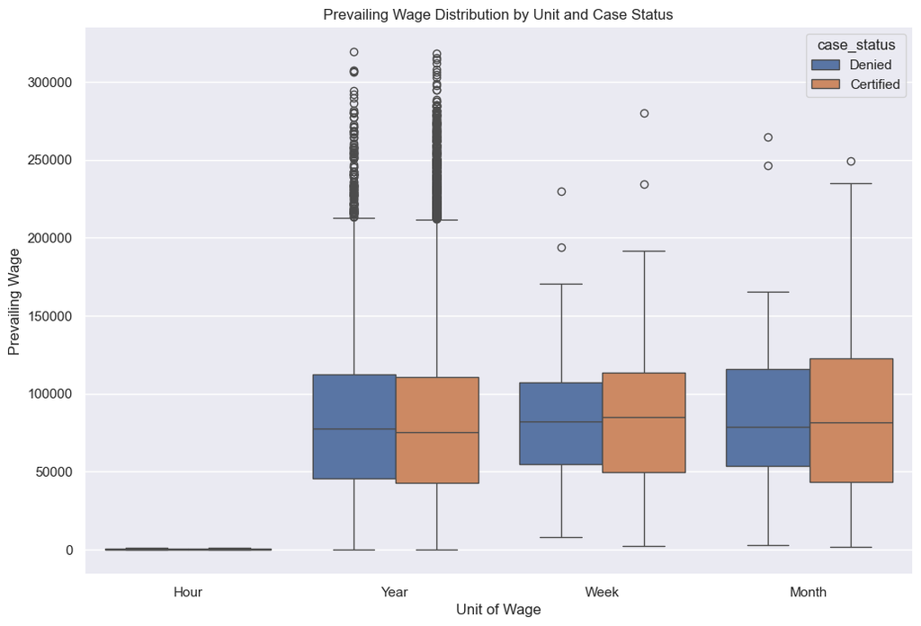

```python
sns.set(rc={"figure.figsize": (12, 8)})

# Group wages by unit_of_wage for separate boxplots
_ = sns.boxplot(x="unit_of_wage", y="prevailing_wage", hue="case_status", data=data_copy, orient="vertical")
_=plt.xlabel("Unit of Wage")
_=plt.ylabel("Prevailing Wage")
_=plt.title("Prevailing Wage Distribution by Unit and Case Status")
plt.show()
```

- Hourly Wages are significantly lower compared to other units, with minimal variation. Both Denied and Certified cases have similar distributions, indicating no clear correlation between hourly wages and case status.
- For Yearly Wages, majority of wages are concentrated below 100,000, with some outliers exceeding 300,000.
- The median wage for certified cases appears slightly lower than denied cases, suggesting that higher yearly wages may not necessarily lead to certification success.
- For Weekly and Monthly Wages, Wider distributions are observed, with certified cases generally having higher median wages than denied cases.
- Outliers are present in all units, particularly for yearly wages, where some values exceed 300,000. These outliers may distort the overall analysis, hence needs further investigation.
- The distribution of wages varies significantly across units, emphasizing the importance of considering unit_of_wage when analyzing prevailing_wage. We will use the engineered feature (normalized_wage) for modeling to standardize wages across units, ensuring consistency.

```python
# function to plot stacked bar chart


def stacked_barplot(data, predictor, target):
    """
    Print the category counts and plot a stacked bar chart

    data: dataframe
    predictor: independent variable
    target: target variable
    """
    count = data[predictor].nunique()
    sorter = data[target].value_counts().index[-1]
    tab1 = pd.crosstab(data[predictor], data[target], margins=True).sort_values(
        by=sorter, ascending=False
    )
    print(tab1)
    print("-" * 120)
    tab = pd.crosstab(data[predictor], data[target], normalize="index").sort_values(
        by=sorter, ascending=False
    )
    tab.plot(kind="bar", stacked=True, figsize=(count + 1, 5))
    plt.legend(
        loc="lower left",
        frameon=False,
    )
    plt.legend(loc="upper left", bbox_to_anchor=(1, 1))
    plt.show()
```

```
case_status    Certified  Denied    All
continent
All                17018    8462  25480
Asia               11012    5849  16861
North America       2037    1255   3292
Europe              2957     775   3732
South America        493     359    852
Africa               397     154    551
Oceania              122      70    192
------------------------------------------------------------------------------------------------------------------------
```

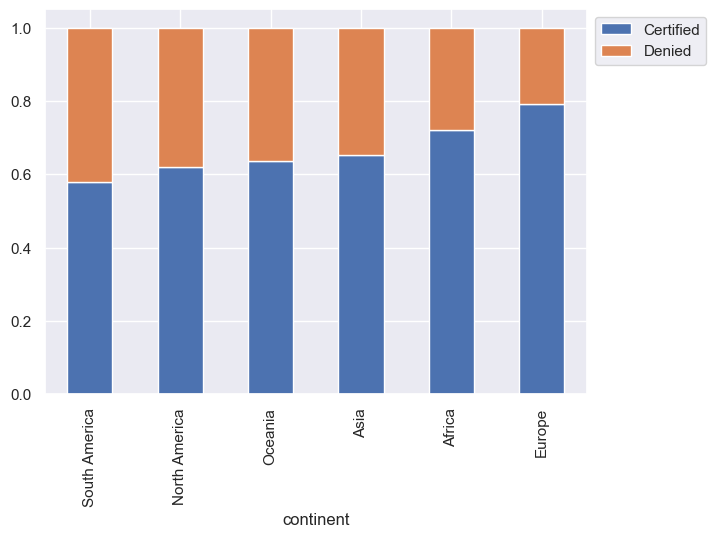

```python
stacked_barplot(data, "continent", "case_status")
```

```
case_status            Certified  Denied    All
education_of_employee
All                        17018    8462  25480
Bachelor's                  6367    3867  10234
High School                 1164    2256   3420
Master's                    7575    2059   9634
Doctorate                   1912     280   2192
------------------------------------------------------------------------------------------------------------------------
```

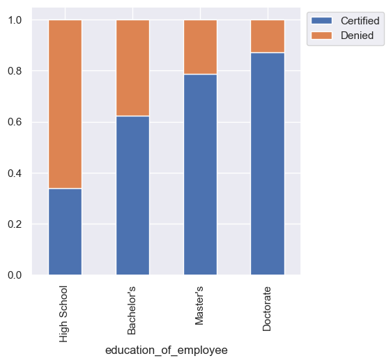

```python
stacked_barplot(data, "education_of_employee", "case_status")
```

- Master's and Doctorate degree holders are significantly more likely to have their cases certified compared to Bachelor's and High School graduates.
- The majority of high school graduates face case denials, highlighting the importance of higher education for certification success.

```
case_status         Certified  Denied    All
has_job_experience
All                     17018    8462  25480
N                        5994    4684  10678
Y                       11024    3778  14802
------------------------------------------------------------------------------------------------------------------------
```

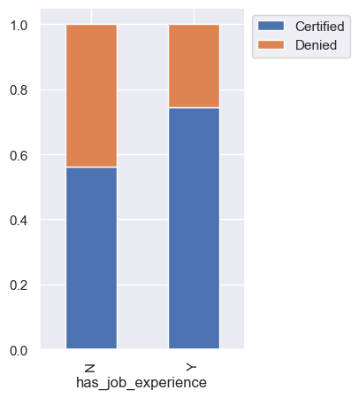

```python
stacked_barplot(data, "has_job_experience", "case_status")
```

- Employees with prior job experience are much more likely to have their cases certified compared to those without experience.
- Lack of job experience appears to be a disadvantage, as inexperienced employees face a higher proportion of denials.

```
case_status            Certified  Denied    All
requires_job_training
All                        17018    8462  25480
N                          15012    7513  22525
Y                           2006     949   2955
------------------------------------------------------------------------------------------------------------------------
```

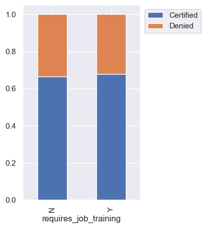

```python
stacked_barplot(data, "requires_job_training", "case_status")
```

- The certification rates for employees requiring job training and those not requiring it are very similar (~67-68%), suggesting that this factor has minimal influence on case outcomes.
- Both groups show similar proportions of certified and denied cases, indicating that job training requirements are not a strong differentiator.

```
case_status           Certified  Denied    All
region_of_employment
All                       17018    8462  25480
Northeast                  4526    2669   7195
West                       4100    2486   6586
South                      4913    2104   7017
Midwest                    3253    1054   4307
Island                      226     149    375
------------------------------------------------------------------------------------------------------------------------
```

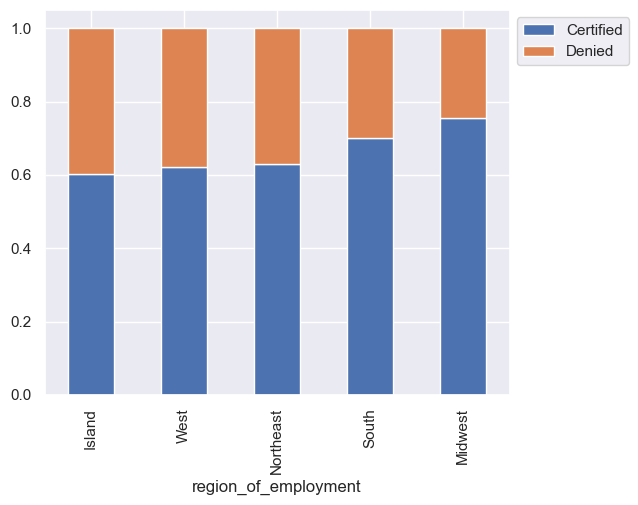

```python
stacked_barplot(data, "region_of_employment", "case_status")
```

- South and Midwest regions Lead in Certification and have the highest certification rates (~70-75%), making them the most favorable for case outcomes.
- The Island region has the lowest certification rate (~60%), suggesting potential barriers to success.
- Moderate Success in West and Northeast regions show balanced certification rates (~62-63%), with room for improvement.

```
case_status   Certified  Denied    All
unit_of_wage
All               17018    8462  25480
Year              16047    6915  22962
Hour                747    1410   2157
Week                169     103    272
Month                55      34     89
------------------------------------------------------------------------------------------------------------------------
```

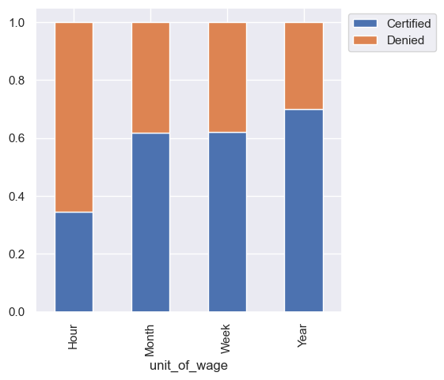

```python
stacked_barplot(data, "unit_of_wage", "case_status")
```

- Applications with yearly wage units have the highest certification rate (~70%), making them the most favorable wage structure.
- Applications with hourly wage units have the lowest certification rate (~35%), highlighting potential barriers to success for this wage structure.
- Both weekly and monthly wage units have similar certification rates (~62%), indicating balanced outcomes.

```
case_status         Certified  Denied    All
full_time_position
All                     17018    8462  25480
Y                       15163    7610  22773
N                        1855     852   2707
------------------------------------------------------------------------------------------------------------------------
```

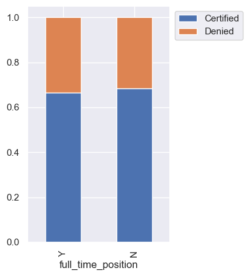

```python
stacked_barplot(data, "full_time_position", "case_status")
```

- Despite being fewer in number, part-time positions have a slightly higher certification rate (~69%) compared to full-time positions (~66%).
- Full-time positions make up the majority of cases, but their certification rate is slightly lower than part-time positions.

#### Correlation Insights

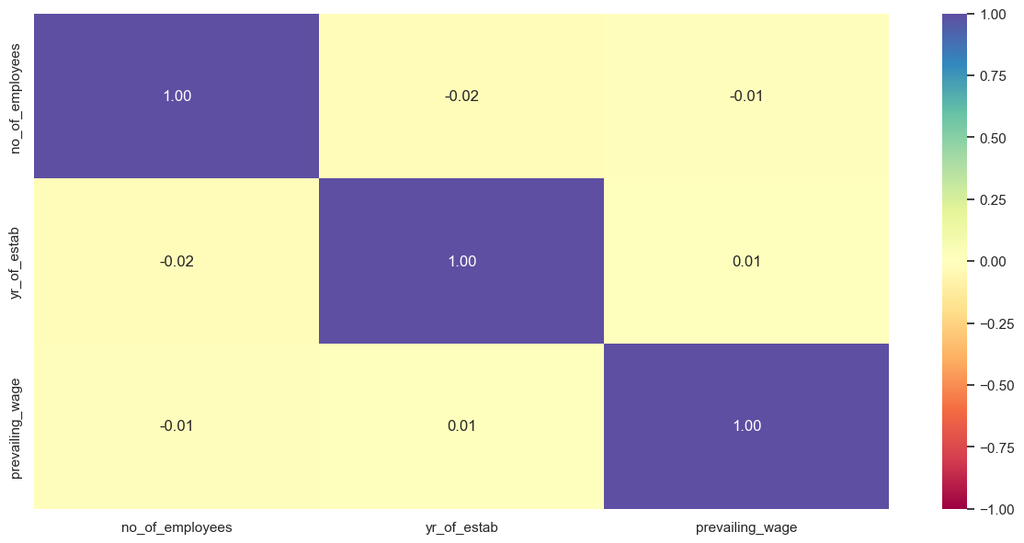

```python
_=plt.figure(figsize=(15, 7))
_=sns.heatmap(data_copy.corr(numeric_only=True), annot=True, vmin=-1, vmax=1, fmt=".2f", cmap="Spectral")
plt.show()
```

- no_of_employees, yr_of_estab, and prevailing_wage show negligible correlations with each other (all values close to 0). This indicates that these numerical features are largely independent and do not influence each other directly.
- The lack of strong correlations suggests that each feature may contribute unique information to the model without redundancy.

### Data PreProcessing

##### Feature Engineering

We can add a few features that might be helpful in the context of this problem.

- employees_per_year -> Captures the relationship between company size (no_of_employees) and maturity (yr_of_estab). Helps identify whether larger, older companies are more likely to succeed in certification.
- normalized_wage -> The original prevailing_wage column has wages expressed in different units (e.g., hourly, weekly, monthly, yearly). Normalizing wages converts them into a consistent unit (e.g., yearly), enabling meaningful comparisons across all rows.
- log_prevailing_wage -> Reduces skewness in the wage distribution, making it easier for models to identify meaningful patterns. Helps handle extreme values in normalized_wage.
- wage_per_employee -> Highlights efficiency or cost per employee, which could influence case outcomes. Provides insight into whether higher wages per employee correlate with certification success.

```python
# Inspect unique units
print(data['unit_of_wage'].unique())
```

```
['Hour' 'Year' 'Week' 'Month']
```

- Wages are in hourly, weekly, monthly and yearly basis.
- We will convert these to yearly basis.

```python
# Define conversion factors
conversion_factors = {
    'Hour': 2080, #Assumes a full-time work schedule of 40 hours per week and 52 weeks per year
    'Week': 52, #52 weeks per year
    'Month': 12, #12 months per year
    'Year': 1 # yearly wages
}

# Normalize prevailing_wage to yearly wages
data['normalized_wage'] = data['prevailing_wage'] * data['unit_of_wage'].map(conversion_factors)
```

```python
# Creating new features

#capture relationship between company size (no_of_employees) and maturity (yr_of_estab)
data['employees_per_year'] = data['no_of_employees'] / (2025 - data['yr_of_estab'])

#Reduce skewness of normalized wage
data['log_prevailing_wage'] = np.log1p(data['normalized_wage'])

#Highlights efficiency or cost per employee
data['wage_per_employee'] = data['normalized_wage'] / data['no_of_employees']
```

##### Handling invalid data rows

- As observed during data overview, employee count is negative for some companies which needs to be handled.
- The number of rows with negative values is small (e.g., <5% of the dataset), dropping them is a simple and effective solution.
- This avoids introducing assumptions or bias into the data.

```python
# Remove Rows with Negative Employee Count
data = data[data['no_of_employees'] >= 0]
```

##### Handling Outliers

- Handling outliers ensures the dataset is clean, representative, and suitable for training robust models without bias from extreme values.
- Outliers in no_of_employees and normalized_wage can skew model predictions and affect decision boundaries.
- Capping extreme values ensures the model focuses on meaningful patterns rather than being influenced by rare, extreme cases.
- Outliers can lead to overfitting, especially in tree-based models, by creating splits that cater to rare values.
- We use +- 1.5 IQR range to filter out the outliers.

```python
# Step 3: Handle Outliers using 1.5 * IQR
def cap_outliers(df, column):
    Q1 = df[column].quantile(0.25)
    Q3 = df[column].quantile(0.75)
    IQR = Q3 - Q1
    lower_bound = Q1 - 1.5 * IQR
    upper_bound = Q3 + 1.5 * IQR
    df[column] = np.where(df[column] < lower_bound, lower_bound, df[column])
    df[column] = np.where(df[column] > upper_bound, upper_bound, df[column])

# Check the existing ranges
print(f"Range for 'no_of_employees': {data['no_of_employees'].min()} to {data['no_of_employees'].max()}")
print(f"Range for 'normalized_wage': {data['normalized_wage'].min()} to {data['normalized_wage'].max()}")

# Apply outlier capping to numerical columns
cap_outliers(data, 'no_of_employees')
cap_outliers(data, 'normalized_wage')

# Check the updated ranges
print(f"Updated range for 'no_of_employees': {data['no_of_employees'].min()} to {data['no_of_employees'].max()}")
print(f"Updated range for 'normalized_wage': {data['normalized_wage'].min()} to {data['normalized_wage'].max()}")
```

```
Range for 'no_of_employees': 12 to 602069
Range for 'normalized_wage': 100.0 to 14569149.4
Updated range for 'no_of_employees': 12.0 to 7228.75
Updated range for 'normalized_wage': 100.0 to 241360.3175
```

##### Drop non useful features

- Since case_id is unique for each case, keeping it adds no valuable information, we will drop it.
- id's are auto generated for each case.

```python
#  Dropping the case_id column as it adds no value to analysis
data = data.drop(["case_id"], axis=1)
```

```python
# Verifying that column was indeed dropped
data.columns
```

```
Index(['continent', 'education_of_employee', 'has_job_experience',
       'requires_job_training', 'no_of_employees', 'yr_of_estab',
       'region_of_employment', 'prevailing_wage', 'unit_of_wage',
       'full_time_position', 'case_status', 'normalized_wage',
       'employees_per_year', 'log_prevailing_wage', 'wage_per_employee'],
      dtype='object')
```

##### PreProcessed Data

```python
# Final Preprocessed Data
print("Preprocessing Complete!")
print(f"Shape of data: {data.shape}")
```

```
Preprocessing Complete!
Shape of data: (25447, 15)
```

- Data has 25447 rows after dropping certain rows during invalid data removal.
- Data now has 15 features which includes engineered features such as
  - 'normalized_wage'
  - 'employees_per_year'
  - 'log_prevailing_wage'
  - 'wage_per_employee'

##### Prepare Target Variable

```python
# case_status needs to be mapped to numerical values to feed to the model
case_status = {"Denied": 0, "Certified": 1}
data["case_status"] = data["case_status"].map(case_status)
```

```python
# Now case_status would have either 0 or 1 values
data['case_status'].unique()
```

```
array([0, 1])
```

##### Data Preparation for Modeling

```python
# Drop the target variable and create separate input and output dataframes.
X = data.drop(["case_status"], axis=1)
y = data["case_status"]
```

```python
X.shape, y.shape
```

```
((25447, 14), (25447,))
```

```python
# Verifying if the target variable was indeed dropped
X.columns
```

```
Index(['continent', 'education_of_employee', 'has_job_experience',
       'requires_job_training', 'no_of_employees', 'yr_of_estab',
       'region_of_employment', 'prevailing_wage', 'unit_of_wage',
       'full_time_position', 'normalized_wage', 'employees_per_year',
       'log_prevailing_wage', 'wage_per_employee'],
      dtype='object')
```

##### Splitting train and test data

```python
# Splitting data into training, validation and test sets:
# first we split data into 2 parts, say temporary and test

X_temp, X_test, y_temp, y_test = train_test_split(
    X, y, test_size=0.2, random_state=1, stratify=y
)

# then we split the temporary set into train and validation

X_train, X_val, y_train, y_val = train_test_split(
    X_temp, y_temp, test_size=0.25, random_state=1, stratify=y_temp
)
print(X_train.shape, X_val.shape, X_test.shape)
```

```
(15267, 14) (5090, 14) (5090, 14)
```

```python
print("Number of rows in train data =", X_train.shape[0])
print("Number of rows in validation data =", X_val.shape[0])
print("Number of rows in test data =", X_test.shape[0])
```

```
Number of rows in train data = 15267
Number of rows in validation data = 5090
Number of rows in test data = 5090
```

##### Encoding Categorical variables

```python
X_train = pd.get_dummies(X_train, drop_first=True)
X_train = X_train.astype(float)

X_val = pd.get_dummies(X_val, drop_first=True)
X_val = X_val.astype(float)

X_test = pd.get_dummies(X_test, drop_first=True)
X_test = X_test.astype(float)
```

- All categorical features have been encoded using one hot encoding.
- Tried label encoding as well but this seems to perform better, hence sticking to it.

### Model evaluation criterion

- You want to be confident that cases you predict as Certified are truly eligible.
- A false positive (predicting "Certified" when it would be denied) wastes time and effort.

Since your model will be used to shortlist candidates for easy approvals, it must trust the prediction of “Certified”.

- Helping prioritize candidates most likely to get certified
- Reducing effort in manually reviewing "almost certain approvals"

### What we should focus on ?

Correctly identifying certified candidates Reducing false denials (i.e., don't wrongly discard good profiles)

#### Model Building with Original data

```python
models = []  # Empty list to store all the models

# Appending models into the list
models.append(("Bagging", BaggingClassifier(random_state=1)))
models.append(("RandomForest", RandomForestClassifier(random_state=1)))
models.append(("GBM", GradientBoostingClassifier(random_state=1)))
models.append(("Adaboost", AdaBoostClassifier(random_state=1)))
models.append(("Xgboost", XGBClassifier(random_state=1, eval_metric="logloss")))
models.append(("DecisionTree", DecisionTreeClassifier(random_state=1)))

results = []  # Empty list to store all model's CV scores
names = []  # Empty list to store name of the models
scores = []

# loop through all models to get the mean cross validated score
# Using cross-validation scores ensures that the model's performance is evaluated in a robust,
# unbiased manner, providing insights into its ability to generalize beyond the training data
print("\n" "Cross-Validation Performance:" "\n")
for name, model in models:
    scoring = "recall"

    # Setting number of splits equal to 5
    kfold = StratifiedKFold(n_splits=5, shuffle=True, random_state=1)
    cv_result = cross_val_score(
        estimator=model, X=X_train, y=y_train, scoring=scoring, cv=kfold
    )
    results.append(cv_result)
    names.append(name)
    print("{}: {:.2f}".format(name, cv_result.mean() * 100))


print("\n" "Validation Performance:" "\n")
for name, model in models:
    _ = model.fit(X_train, y_train)
    score = recall_score(y_val, model.predict(X_val))
    scores.append(score)
    print("{}: {:.2f}".format(name, score*100))
```

```
Cross-Validation Performance:

Bagging: 77.26
RandomForest: 84.52
GBM: 87.38
Adaboost: 89.14
Xgboost: 84.69
DecisionTree: 73.78

Validation Performance:

Bagging: 78.80
RandomForest: 84.56
GBM: 87.89
Adaboost: 90.68
Xgboost: 85.30
DecisionTree: 73.68
```

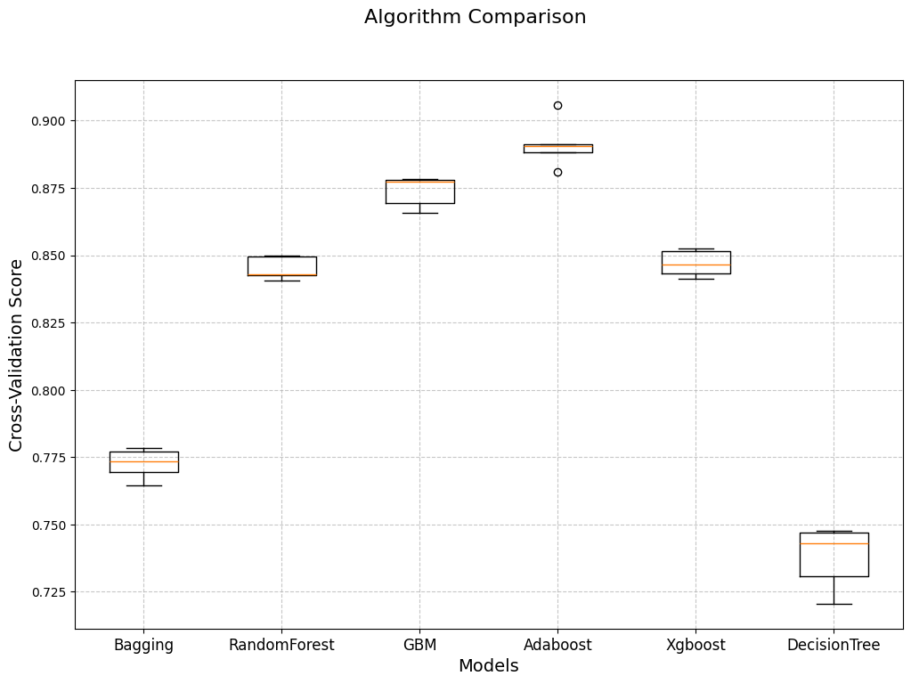

```python
# Plotting boxplots for CV scores of all models
fig = plt.figure(figsize=(12, 8))  # Increase figure size for better visualization
_ = fig.suptitle("Algorithm Comparison", fontsize=16)  # Larger title for clarity
ax = fig.add_subplot(111)
_ = plt.boxplot(results)
_ = ax.set_xticklabels(names, fontsize=12)  # Increase font size for labels

# Add gridlines for better readability
ax.grid(True, linestyle='--', alpha=0.7)  # Enable both horizontal and vertical gridlines

plt.xlabel("Models", fontsize=14)
plt.ylabel("Cross-Validation Score", fontsize=14)
plt.show()
```

```python
# Initialize an empty list to store the results
results_table = []

# Calculate training and validation performance and store in the results table
for name, model in models:
    _ = model.fit(X_train, y_train)
    scores_train = recall_score(y_train, model.predict(X_train))
    scores_val = recall_score(y_val, model.predict(X_val))
    difference = scores_train - scores_val
    results_table.append([name, scores_train, scores_val, difference])

# Convert the results into a pandas DataFrame for tabular display
results_df = pd.DataFrame(results_table, columns=["Model", "Training Score", "Validation Score", "Difference"])

# Display the results in a tabular format
print("\nTraining and Validation Performance Difference:\n")
print(results_df.to_string(index=False))
```

```
Training and Validation Performance Difference:

       Model  Training Score  Validation Score  Difference
     Bagging           0.988             0.788       0.200
RandomForest           1.000             0.846       0.154
         GBM           0.879             0.879       0.001
    Adaboost           0.905             0.907      -0.002
     Xgboost           0.949             0.853       0.096
DecisionTree           1.000             0.737       0.263
```

**Observations**

#### Models Building - Oversampled Data

```python
print("Before Oversampling, counts of label 'Yes': {}".format(sum(y_train == 1)))
print("Before Oversampling, counts of label 'No': {} \n".format(sum(y_train == 0)))

sm = SMOTE(
    sampling_strategy=1, k_neighbors=5, random_state=1
)  # Synthetic Minority Over Sampling Technique
X_train_over, y_train_over = sm.fit_resample(X_train, y_train)


print("After Oversampling, counts of label 'Yes': {}".format(sum(y_train_over == 1)))
print("After Oversampling, counts of label 'No': {} \n".format(sum(y_train_over == 0)))


print("After Oversampling, the shape of train_X: {}".format(X_train_over.shape))
print("After Oversampling, the shape of train_y: {} \n".format(y_train_over.shape))
```

```
Before Oversampling, counts of label 'Yes': 10199
Before Oversampling, counts of label 'No': 5068

After Oversampling, counts of label 'Yes': 10199
After Oversampling, counts of label 'No': 10199

After Oversampling, the shape of train_X: (20398, 25)
After Oversampling, the shape of train_y: (20398,)
```

```python
models = []  # Empty list to store all the models

# Appending models into the list
models.append(("Bagging", BaggingClassifier(random_state=1)))
models.append(("RandomForest", RandomForestClassifier(random_state=1)))
models.append(("GBM", GradientBoostingClassifier(random_state=1)))
models.append(("Adaboost", AdaBoostClassifier(random_state=1)))
models.append(("Xgboost", XGBClassifier(random_state=1, eval_metric="logloss")))
models.append(("DecisionTree", DecisionTreeClassifier(random_state=1)))

results = []  # Empty list to store all model's CV scores
names = []  # Empty list to store name of the models
score = []

# loop through all models to get the mean cross validated score
print("\n" "Cross-Validation Performance:" "\n")
for name, model in models:
    scoring = "recall"

    # Setting number of splits equal to 5
    kfold = StratifiedKFold(n_splits=5, shuffle=True, random_state=1)
    cv_result = cross_val_score(
        estimator=model, X=X_train_over, y=y_train_over, scoring=scoring, cv=kfold
    )
    results.append(cv_result)
    names.append(name)
    print("{}: {:.2f}".format(name, cv_result.mean() * 100))

print("\n" "Validation Performance:" "\n")
for name, model in models:
    _ = model.fit(X_train_over, y_train_over)
    scores = recall_score(y_val, model.predict(X_val))
    score.append(scores)
    print("{}: {:.2f}".format(name, scores))
```

```
Cross-Validation Performance:

Bagging: 76.87
RandomForest: 83.43
GBM: 85.76
Adaboost: 83.69
Xgboost: 83.74
DecisionTree: 74.24

Validation Performance:

Bagging: 0.78
RandomForest: 0.84
GBM: 0.86
Adaboost: 0.85
Xgboost: 0.85
DecisionTree: 0.74
```

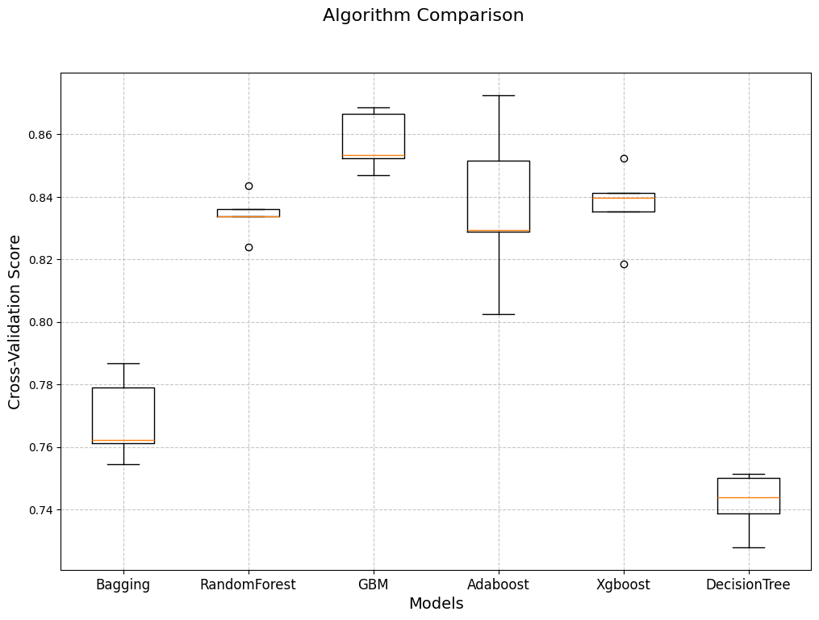

```python
# Plotting boxplots for CV scores of all models
fig = plt.figure(figsize=(12, 8))  # Increase figure size for better visualization
_ = fig.suptitle("Algorithm Comparison", fontsize=16)  # Larger title for clarity
ax = fig.add_subplot(111)
_ = plt.boxplot(results)
_ = ax.set_xticklabels(names, fontsize=12)  # Increase font size for labels

# Add gridlines for better readability
ax.grid(True, linestyle='--', alpha=0.7)  # Enable both horizontal and vertical gridlines

plt.xlabel("Models", fontsize=14)
plt.ylabel("Cross-Validation Score", fontsize=14)
plt.show()
```

```python
# Initialize an empty list to store the results
results_table = []

# Calculate training and validation performance and store in the results table
for name, model in models:
    _ = model.fit(X_train_over, y_train_over)
    scores_train = recall_score(y_train_over, model.predict(X_train_over))
    scores_val = recall_score(y_val, model.predict(X_val))
    difference = scores_train - scores_val
    results_table.append([name, scores_train, scores_val, difference])

# Convert the results into a pandas DataFrame for tabular display
results_df = pd.DataFrame(results_table, columns=["Model", "Training Score", "Validation Score", "Difference"])

# Display the results in a tabular format
print("\nTraining and Validation Performance Difference:\n")
print(results_df.to_string(index=False))
```

```
Training and Validation Performance Difference:

       Model  Training Score  Validation Score  Difference
     Bagging           0.985             0.777       0.208
RandomForest           1.000             0.843       0.157
         GBM           0.865             0.864       0.000
    Adaboost           0.847             0.853      -0.007
     Xgboost           0.935             0.847       0.088
DecisionTree           1.000             0.742       0.258
```

**Observations**

#### Model Building - Undersampled Data

```python
rus = RandomUnderSampler(random_state=1)
X_train_un, y_train_un = rus.fit_resample(X_train, y_train)

print("Before Under Sampling, counts of label 'Yes': {}".format(sum(y_train == 1)))
print("Before Under Sampling, counts of label 'No': {} \n".format(sum(y_train == 0)))

print("After Under Sampling, counts of label 'Yes': {}".format(sum(y_train_un == 1)))
print("After Under Sampling, counts of label 'No': {} \n".format(sum(y_train_un == 0)))

print("After Under Sampling, the shape of train_X: {}".format(X_train_un.shape))
print("After Under Sampling, the shape of train_y: {} \n".format(y_train_un.shape))
```

```
Before Under Sampling, counts of label 'Yes': 10199
Before Under Sampling, counts of label 'No': 5068

After Under Sampling, counts of label 'Yes': 5068
After Under Sampling, counts of label 'No': 5068

After Under Sampling, the shape of train_X: (10136, 25)
After Under Sampling, the shape of train_y: (10136,)
```

```python
models = []  # Empty list to store all the models

# Appending models into the list
models.append(("Bagging", BaggingClassifier(random_state=1)))
models.append(("RandomForest", RandomForestClassifier(random_state=1)))
models.append(("GBM", GradientBoostingClassifier(random_state=1)))
models.append(("Adaboost", AdaBoostClassifier(random_state=1)))
models.append(("Xgboost", XGBClassifier(random_state=1, eval_metric="logloss")))
models.append(("DecisionTree", DecisionTreeClassifier(random_state=1)))

results = []  # Empty list to store all model's CV scores
names = []  # Empty list to store name of the models
score = []

# loop through all models to get the mean cross validated score
print("\n" "Cross-Validation Performance:" "\n")
for name, model in models:
    scoring = "recall"

    # Setting number of splits equal to 5
    kfold = StratifiedKFold(n_splits=5, shuffle=True, random_state=1)
    cv_result = cross_val_score(
        estimator=model, X=X_train_un, y=y_train_un, scoring=scoring, cv=kfold
    )
    results.append(cv_result)
    names.append(name)
    print("{}: {:.2f}".format(name, cv_result.mean() * 100))

print("\n" "Validation Performance:" "\n")
for name, model in models:
    _ = model.fit(X_train_un, y_train_un)
    scores = recall_score(y_val, model.predict(X_val))
    score.append(scores)
    print("{}: {:.2f}".format(name, scores))
```

```
Cross-Validation Performance:

Bagging: 60.62
RandomForest: 66.53
GBM: 71.86
Adaboost: 72.45
Xgboost: 67.30
DecisionTree: 62.71

Validation Performance:

Bagging: 0.62
RandomForest: 0.68
GBM: 0.73
Adaboost: 0.71
Xgboost: 0.69
DecisionTree: 0.62
```

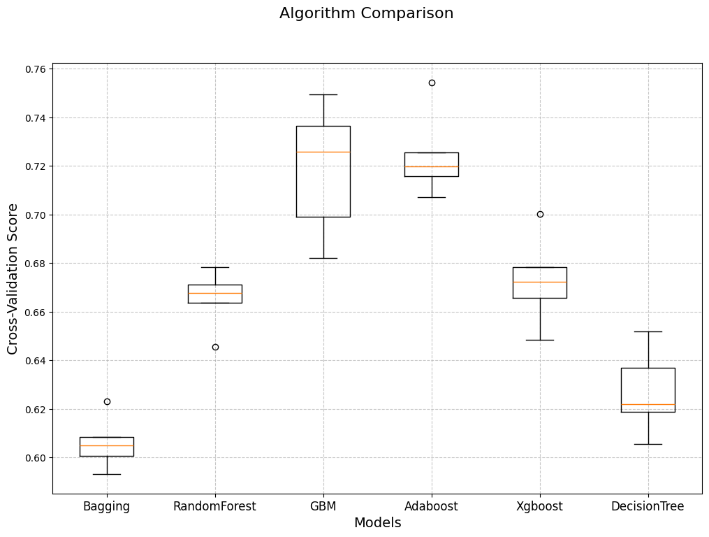

```python
# Plotting boxplots for CV scores of all models
fig = plt.figure(figsize=(12, 8))  # Increase figure size for better visualization
_ = fig.suptitle("Algorithm Comparison", fontsize=16)  # Larger title for clarity
ax = fig.add_subplot(111)
_ = plt.boxplot(results)
_ = ax.set_xticklabels(names, fontsize=12)  # Increase font size for labels

# Add gridlines for better readability
ax.grid(True, linestyle='--', alpha=0.7)  # Enable both horizontal and vertical gridlines

plt.xlabel("Models", fontsize=14)
plt.ylabel("Cross-Validation Score", fontsize=14)
plt.show()
```

```python
# Initialize an empty list to store the results
results_table = []

# Calculate training and validation performance and store in the results table
for name, model in models:
    _ = model.fit(X_train_un, y_train_un)
    scores_train = recall_score(y_train_un, model.predict(X_train_un))
    scores_val = recall_score(y_val, model.predict(X_val))
    difference = scores_train - scores_val
    results_table.append([name, scores_train, scores_val, difference])

# Convert the results into a pandas DataFrame for tabular display
results_df = pd.DataFrame(results_table, columns=["Model", "Training Score", "Validation Score", "Difference"])

# Display the results in a tabular format
print("\nTraining and Validation Performance Difference:\n")
print(results_df.to_string(index=False))
```

```
Training and Validation Performance Difference:

       Model  Training Score  Validation Score  Difference
     Bagging           0.967             0.621       0.346
RandomForest           1.000             0.677       0.323
         GBM           0.747             0.731       0.016
    Adaboost           0.703             0.714      -0.010
     Xgboost           0.891             0.687       0.203
DecisionTree           1.000             0.622       0.378
```

**Observations**

### Hyperparameter Tuning

- Here is the snapshot indicating the performance of best performing models across original and oversampled data.
- This doesn't include any model on undersampled data since they performance was bad compared to models trained on orginal and oversampled data.

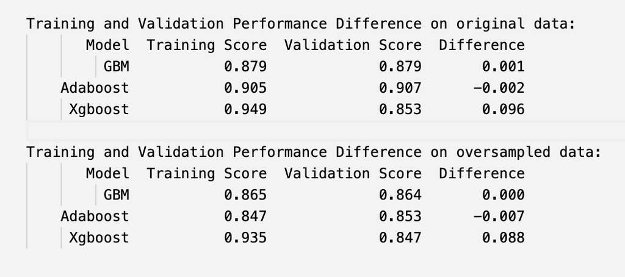

- GBM has the most consistent performance with stable results.
- Adaboost has the highest performance on validation set for original data with minimal variability.
- Xgboost has relatively inferior performance but is still much better than models such as Bagging, decision trees etc.
- All models seem to perform consistently on both original data and oversampled data.

**First let's create two functions to calculate different metrics and confusion matrix, so that we don't have to use the same code repeatedly for each model.**

##### Helper functions

```python
# defining a function to compute different metrics to check performance of a classification model built using sklearn
def model_performance_classification_sklearn(model, predictors, target):
    """
    Function to compute different metrics to check classification model performance

    model: classifier
    predictors: independent variables
    target: dependent variable
    """

    # predicting using the independent variables
    pred = model.predict(predictors)

    acc = accuracy_score(target, pred)  # to compute Accuracy
    recall = recall_score(target, pred)  # to compute Recall
    precision = precision_score(target, pred)  # to compute Precision
    f1 = f1_score(target, pred)  # to compute F1-score

    # creating a dataframe of metrics
    df_perf = pd.DataFrame(
        {
            "Accuracy": acc,
            "Recall": recall,
            "Precision": precision,
            "F1": f1,
        },
        index=[0],
    )

    return df_perf
```

```python
def confusion_matrix_sklearn(model, predictors, target):
    """
    To plot the confusion_matrix with percentages

    model: classifier
    predictors: independent variables
    target: dependent variable
    """
    y_pred = model.predict(predictors)
    cm = confusion_matrix(target, y_pred)
    labels = np.asarray(
        [
            ["{0:0.0f}".format(item) + "\n{0:.2%}".format(item / cm.flatten().sum())]
            for item in cm.flatten()
        ]
    ).reshape(2, 2)

    plt.figure(figsize=(6, 4))
    sns.heatmap(cm, annot=labels, fmt="")
    plt.ylabel("True label")
    plt.xlabel("Predicted label")
```

```python
def run_hyperparameter_search(model, param_grid, X, y, search_type='grid', scoring='accuracy', cv=5, n_iter=50):
    """
    Run GridSearchCV or RandomizedSearchCV for hyperparameter tuning.

    Parameters:
    - model: Base model to optimize.
    - param_grid: Dictionary of hyperparameters to search.
    - X_train: Training feature set.
    - y_train: Training target set.
    - search_type: 'grid' for GridSearchCV or 'random' for RandomizedSearchCV (default: 'grid').
    - scoring: Metric to optimize (default: 'accuracy').
    - cv: Number of cross-validation folds (default: 5).
    - n_iter: Number of iterations for RandomizedSearchCV (default: 50).

    Returns:
    - best_params: Dictionary of best hyperparameters.
    - best_model: Trained model with best hyperparameters.
    """
    if search_type == 'grid':
        search = GridSearchCV(
            estimator=model,
            param_grid=param_grid,
            scoring=scoring,
            cv=cv,
            verbose=1,
            n_jobs=-1
        )
    elif search_type == 'random':
        search = RandomizedSearchCV(
            estimator=model,
            param_distributions=param_grid,
            scoring=scoring,
            cv=cv,
            n_iter=n_iter,
            random_state=1,
            verbose=1,
            n_jobs=-1
        )
    else:
        raise ValueError("Invalid search_type. Use 'grid' or 'random'.")

    # Fit the search object
    search.fit(X, y)

    return search.best_params_, search.best_estimator_
```

```python
def run_and_display_results(model, param_grid, X_train, y_train, X_val, y_val, search_type='grid', scoring='accuracy', cv=5, n_iter=50):
    """
    Run hyperparameter search for a data + model combination and display results.

    Parameters:
    - model: Base model to optimize.
    - param_grid: Dictionary of hyperparameters to search.
    - X_train: Training feature set.
    - y_train: Training target set.
    - X_val: Validation feature set.
    - y_val: Validation target set.
    - search_type: 'grid' for GridSearchCV or 'random' for RandomizedSearchCV (default: 'grid').
    - scoring: Metric to optimize (default: 'accuracy').
    - cv: Number of cross-validation folds (default: 5).
    - n_iter: Number of iterations for RandomizedSearchCV (default: 50).

    Returns:
    - None (prints results directly).
    """
    # Run hyperparameter search
    best_params, best_model = run_hyperparameter_search(
        model=model,
        param_grid=param_grid,
        X=X_train,
        y=y_train,
        search_type=search_type,
        scoring=scoring,
        cv=cv,
        n_iter=n_iter
    )


    # Extract the class type of the base model
    model_class = type(model)

    # Reinitialize the model with best parameters
    tuned_model = model_class(**best_params, random_state=1)

    tuned_model.fit(X_train, y_train)


    # Print results
    print(f"\n\nModel: {model.__class__.__name__}")
    print(f"\nSearch Type: {search_type}")
    print(f"\nBest Parameters:\n {pd.DataFrame(best_params.items(), columns=["Hyperparameter", "Value"])}\n")

    # Checking model's performance on training set
    train_metrics = model_performance_classification_sklearn(
        tuned_model, X_train, y_train
    )
    print("\nTraining metrics:")
    print(train_metrics)

    # Checking model's performance on validation set
    val_metrics = model_performance_classification_sklearn(
        tuned_model, X_val, y_val
        )
    print("\nValidation metrics:")
    print(val_metrics)


    # creating confusion matrix
    print("\nConfusion Matrix:")
    confusion_matrix_sklearn(tuned_model, X_val, y_val)

    return tuned_model, train_metrics, val_metrics
```

#### Tuning Gradient Boosting machine(GBM) model with original data

##### Parameter tuning using RandomSearchCV

```
Fitting 5 folds for each of 50 candidates, totalling 250 fits


Model: GradientBoostingClassifier

Search Type: random

Best Parameters:
   Hyperparameter                                              Value
0      subsample                                              0.900
1   n_estimators                                                 50
2   max_features                                                  1
3  learning_rate                                              0.010
4           init  (DecisionTreeClassifier(max_depth=1, random_st...


Training metrics:
   Accuracy  Recall  Precision    F1
0     0.722   0.938      0.726 0.818

Validation metrics:
   Accuracy  Recall  Precision    F1
0     0.723   0.938      0.727 0.819

Confusion Matrix:
```

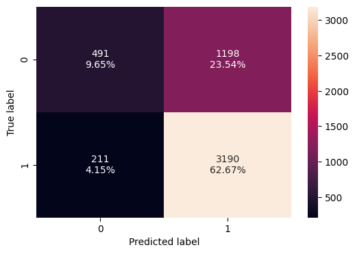

```python
# Define model and hyperparameter grid
model = GradientBoostingClassifier(random_state=1)
#Parameter grid to pass in RandomSearchCV
param_grid = {
    "init": [AdaBoostClassifier(random_state=1),
             DecisionTreeClassifier(random_state=1)],
    "n_estimators": np.arange(50,125,25),
    "learning_rate": [0.01, 0.2, 0.05, 1],
    "subsample":[0.8,0.9,1],
    "max_features":[0.5,0.7,1],
}

# Type of scoring used to compare parameter combinations
scorer = metrics.make_scorer(metrics.recall_score)

# Run and display results
tuned_gbm1, gbm1_train, gbm1_val = run_and_display_results(
    model=model,
    param_grid=param_grid,
    X_train=X_train,
    y_train=y_train,
    X_val=X_val,
    y_val=y_val,
    search_type='random',
    scoring=scorer,
    cv=5
)
```

##### Parameter tuning using GridSearchCV

```
Fitting 5 folds for each of 216 candidates, totalling 1080 fits


Model: GradientBoostingClassifier

Search Type: grid

Best Parameters:
   Hyperparameter                                              Value
0           init  (DecisionTreeClassifier(max_depth=1, random_st...
1  learning_rate                                              0.010
2   max_features                                                  1
3   n_estimators                                                100
4      subsample                                              0.900


Training metrics:
   Accuracy  Recall  Precision    F1
0     0.720   0.939      0.724 0.818

Validation metrics:
   Accuracy  Recall  Precision    F1
0     0.721   0.938      0.725 0.818

Confusion Matrix:
```

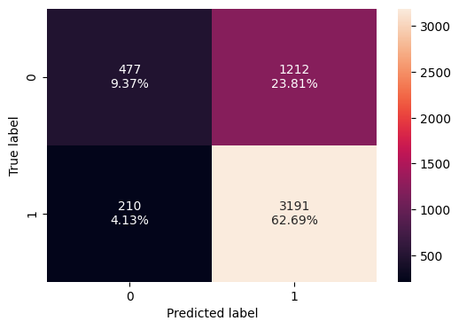

```python
# Define model and hyperparameter grid
model = GradientBoostingClassifier(random_state=1)

#Parameter grid to pass in RandomSearchCV
param_grid = {
    "init": [AdaBoostClassifier(random_state=1),
             DecisionTreeClassifier(random_state=1)],
    "n_estimators": [50, 75, 100],
    "learning_rate": [0.01, 0.2, 0.05, 1],
    "subsample":[0.8,0.9,1],
    "max_features":[0.5,0.7,1],
}

# Type of scoring used to compare parameter combinations
scorer = metrics.make_scorer(metrics.recall_score)

# Run and display results
tuned_gbm2, gbm2_train, gbm2_val = run_and_display_results(
    model=model,
    param_grid=param_grid,
    X_train=X_train,
    y_train=y_train,
    X_val=X_val,
    y_val=y_val,
    search_type='grid',
    scoring=scorer,
    cv=5
)
```

#### Tuning Gradient Boosting machine(GBM) model with oversampled data

##### Parameter tuning using RandomSearchCV

```
Fitting 5 folds for each of 50 candidates, totalling 250 fits


Model: GradientBoostingClassifier

Search Type: random

Best Parameters:
   Hyperparameter                                              Value
0      subsample                                              0.900
1   n_estimators                                                 50
2   max_features                                                  1
3  learning_rate                                              0.010
4           init  (DecisionTreeClassifier(max_depth=1, random_st...


Training metrics:
   Accuracy  Recall  Precision    F1
0     0.797   0.857      0.765 0.808

Validation metrics:
   Accuracy  Recall  Precision    F1
0     0.740   0.859      0.775 0.815

Confusion Matrix:
```

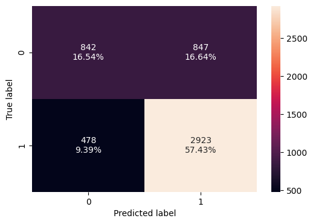

```python
# Define model and hyperparameter grid
model = GradientBoostingClassifier(random_state=1)
#Parameter grid to pass in RandomSearchCV
param_grid = {
    "init": [AdaBoostClassifier(random_state=1),
             DecisionTreeClassifier(random_state=1)],
    "n_estimators": np.arange(50,125,25),
    "learning_rate": [0.01, 0.2, 0.05, 1],
    "subsample":[0.8,0.9,1],
    "max_features":[0.5,0.7,1],
}

# Type of scoring used to compare parameter combinations
scorer = metrics.make_scorer(metrics.recall_score)

# Run and display results
tuned_gbm3, gbm3_train, gbm3_val = run_and_display_results(
    model=model,
    param_grid=param_grid,
    X_train=X_train_over,
    y_train=y_train_over,
    X_val=X_val,
    y_val=y_val,
    search_type='random',
    scoring=scorer,
    cv=5
)
```

##### Parameter tuning using GridSearchCV

```
Fitting 5 folds for each of 216 candidates, totalling 1080 fits


Model: GradientBoostingClassifier

Search Type: grid

Best Parameters:
   Hyperparameter                                              Value
0           init  (DecisionTreeClassifier(max_depth=1, random_st...
1  learning_rate                                              0.010
2   max_features                                                  1
3   n_estimators                                                100
4      subsample                                                  1


Training metrics:
   Accuracy  Recall  Precision    F1
0     0.795   0.866      0.758 0.808

Validation metrics:
   Accuracy  Recall  Precision    F1
0     0.743   0.874      0.771 0.820

Confusion Matrix:
```

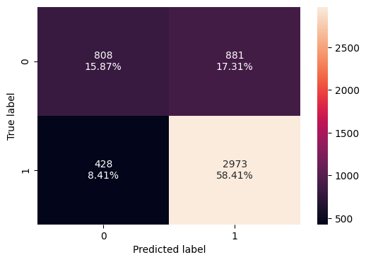

```python
# Define model and hyperparameter grid
model = GradientBoostingClassifier(random_state=1)

#Parameter grid to pass in RandomSearchCV
param_grid = {
    "init": [AdaBoostClassifier(random_state=1),
             DecisionTreeClassifier(random_state=1)],
    "n_estimators": [50, 75, 100],
    "learning_rate": [0.01, 0.2, 0.05, 1],
    "subsample":[0.8,0.9,1],
    "max_features":[0.5,0.7,1],
}

# Type of scoring used to compare parameter combinations
scorer = metrics.make_scorer(metrics.recall_score)

# Run and display results
tuned_gbm4, gbm4_train, gbm4_val = run_and_display_results(
    model=model,
    param_grid=param_grid,
    X_train=X_train_over,
    y_train=y_train_over,
    X_val=X_val,
    y_val=y_val,
    search_type='grid',
    scoring=scorer,
    cv=5
)
```